# Transformación y estandarización de Datos

Pablo Mora

2022-05-25

# Determinación y visualización de NAs

## Cargar datos

```r
data("airquality")
str(airquality)
```

```
## 'data.frame':    153 obs. of  6 variables:
##  $ Ozone  : int  41 36 12 18 NA 28 23 19 8 NA ...
##  $ Solar.R: int  190 118 149 313 NA NA 299 99 19 194 ...
##  $ Wind   : num  7.4 8 12.6 11.5 14.3 14.9 8.6 13.8 20.1 8.6 ...
##  $ Temp   : int  67 72 74 62 56 66 65 59 61 69 ...
##  $ Month  : int  5 5 5 5 5 5 5 5 5 5 ...
##  $ Day    : int  1 2 3 4 5 6 7 8 9 10 ...
```

## Cantidad de NAs por variable

```r
library(dplyr)
valoresNA <- airquality %>%
             summarise(
                across(.cols = everything(),
                .fns = ~sum(is.na(.), na.rm = FALSE)))
valoresNA
```

```
##   Ozone Solar.R Wind Temp Month Day
## 1    37       7    0    0     0   0
```

### Graficación frecuencia de NAs por variable

Se puede observar que solo las variables Ozone y Solar.R tienen NAs

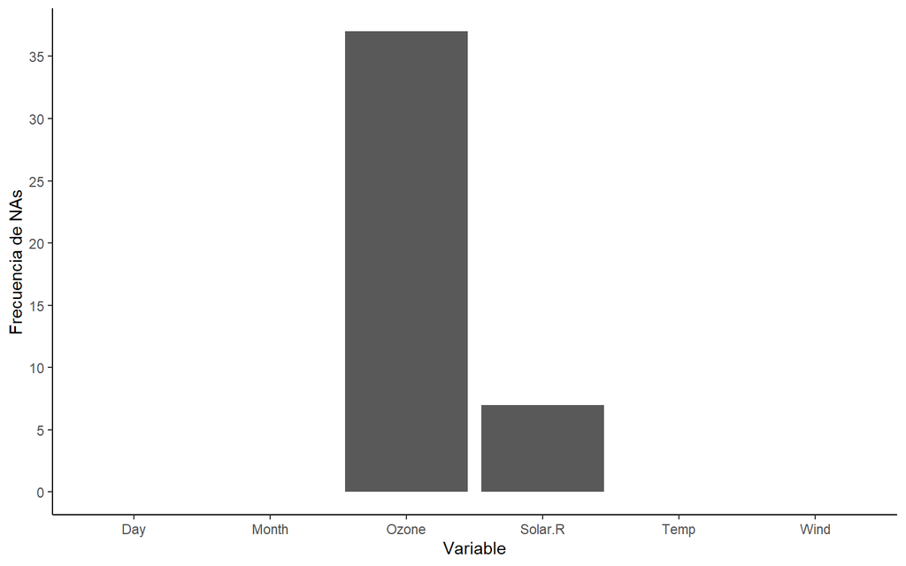

```r
library(ggplot2)
library(tidyr)

valoresNA %>%
  pivot_longer(everything(),
                           names_to ="Variable",
                           values_to ="Frecuencia") %>%
  ggplot(aes(x = Variable, y = Frecuencia), colour = Variable) +
  geom_col() +
  labs(y = "Frecuencia de NAs") +
  scale_y_continuous(breaks = seq(0, 40, 5)) +
  theme_classic()
```

# Imputación

## Imputación simple

Para determinar que método de imputación simple se puede usar, primero se usaron boxplots para ver la distribución de los datos.

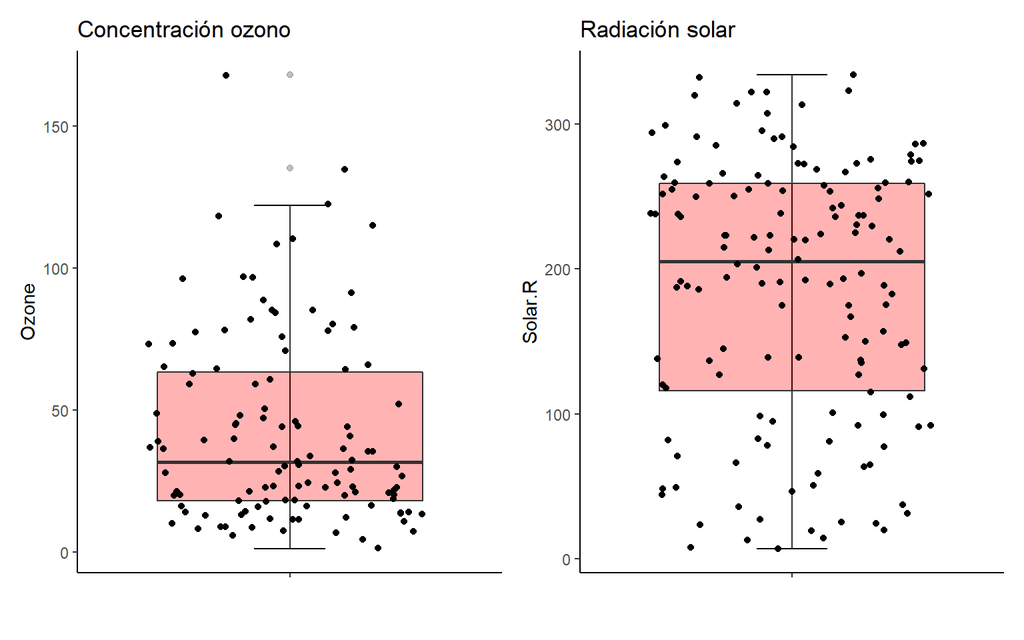

```r
library(patchwork)
#Gráfico de barras para Ozone
graph1 <- airquality %>%
  drop_na(Ozone) %>%
  ggplot(aes(x="", y=Ozone)) +
  stat_boxplot(geom = "errorbar",
               width = 0.2) +
  geom_boxplot(fill="red", alpha = 0.3) +
  geom_jitter() +
  labs(x = "") +
  ggtitle("Concentración ozono") +
  theme_classic()

#Gráfico de barras para Solar.R
graph2 <- airquality %>%
  drop_na(Solar.R) %>%
  ggplot(aes(x="", y=Solar.R)) +
  stat_boxplot(geom = "errorbar",
               width = 0.2) +
  geom_boxplot(fill="red", alpha = 0.3) +
  geom_jitter() +
  labs(x = "") +
  ggtitle("Radiación solar") +
  theme_classic()

graph1+graph2
```

La variable Ozone tiene unos pocos outliers, por lo que para el ozono vamos a usar la mediana para la imputación.

### Imputación con Hmisc para Ozone

```r
library(Hmisc)

airquality.mis = airquality
airquality.mis$Ozone <- impute(airquality$Ozone, median) #Se usó la mediana
airquality.mis$Ozone
```

```
##   [1]  41.0   36.0   12.0   18.0   31.5*  28.0   23.0   19.0    8.0   31.5*
##  [11]   7.0   16.0   11.0   14.0   18.0   14.0   34.0    6.0   30.0   11.0
##  [21]   1.0   11.0    4.0   32.0   31.5*  31.5*  31.5*  23.0   45.0  115.0
##  [31]  37.0   31.5*  31.5*  31.5*  31.5*  31.5*  31.5*  29.0   31.5*  71.0
##  [41]  39.0   31.5*  31.5*  23.0   31.5*  31.5*  21.0   37.0   20.0   12.0
##  [51]  13.0   31.5*  31.5*  31.5*  31.5*  31.5*  31.5*  31.5*  31.5*  31.5*
##  [61]  31.5* 135.0   49.0   32.0   31.5*  64.0   40.0   77.0   97.0   97.0
##  [71]  85.0   31.5*  10.0   27.0   31.5*   7.0   48.0   35.0   61.0   79.0
##  [81]  63.0   16.0   31.5*  31.5*  80.0  108.0   20.0   52.0   82.0   50.0
##  [91]  64.0   59.0   39.0    9.0   16.0   78.0   35.0   66.0  122.0   89.0
## [101] 110.0   31.5*  31.5*  44.0   28.0   65.0   31.5*  22.0   59.0   23.0
## [111]  31.0   44.0   21.0    9.0   31.5*  45.0  168.0   73.0   31.5*  76.0
## [121] 118.0   84.0   85.0   96.0   78.0   73.0   91.0   47.0   32.0   20.0
## [131]  23.0   21.0   24.0   44.0   21.0   28.0    9.0   13.0   46.0   18.0
## [141]  13.0   24.0   16.0   13.0   23.0   36.0    7.0   14.0   30.0   31.5*
## [151]  14.0   18.0   20.0
```

### Imputación con Hmisc para Solar.R

```r
airquality.mis$Solar.R <- impute(airquality$Solar.R, mean) #Se usó el promedio
airquality.mis$Solar.R
```

```
##   [1] 190.0000  118.0000  149.0000  313.0000  185.9315* 185.9315* 299.0000
##   [8]  99.0000   19.0000  194.0000  185.9315* 256.0000  290.0000  274.0000
##  [15]  65.0000  334.0000  307.0000   78.0000  322.0000   44.0000    8.0000
##  [22] 320.0000   25.0000   92.0000   66.0000  266.0000  185.9315*  13.0000
##  [29] 252.0000  223.0000  279.0000  286.0000  287.0000  242.0000  186.0000
##  [36] 220.0000  264.0000  127.0000  273.0000  291.0000  323.0000  259.0000
##  [43] 250.0000  148.0000  332.0000  322.0000  191.0000  284.0000   37.0000
##  [50] 120.0000  137.0000  150.0000   59.0000   91.0000  250.0000  135.0000
##  [57] 127.0000   47.0000   98.0000   31.0000  138.0000  269.0000  248.0000
##  [64] 236.0000  101.0000  175.0000  314.0000  276.0000  267.0000  272.0000
##  [71] 175.0000  139.0000  264.0000  175.0000  291.0000   48.0000  260.0000
##  [78] 274.0000  285.0000  187.0000  220.0000    7.0000  258.0000  295.0000
##  [85] 294.0000  223.0000   81.0000   82.0000  213.0000  275.0000  253.0000
##  [92] 254.0000   83.0000   24.0000   77.0000  185.9315* 185.9315* 185.9315*
##  [99] 255.0000  229.0000  207.0000  222.0000  137.0000  192.0000  273.0000
## [106] 157.0000   64.0000   71.0000   51.0000  115.0000  244.0000  190.0000
## [113] 259.0000   36.0000  255.0000  212.0000  238.0000  215.0000  153.0000
## [120] 203.0000  225.0000  237.0000  188.0000  167.0000  197.0000  183.0000
## [127] 189.0000   95.0000   92.0000  252.0000  220.0000  230.0000  259.0000
## [134] 236.0000  259.0000  238.0000   24.0000  112.0000  237.0000  224.0000
## [141]  27.0000  238.0000  201.0000  238.0000   14.0000  139.0000   49.0000
## [148]  20.0000  193.0000  145.0000  191.0000  131.0000  223.0000
```

## Imputación por modelado con misc

```r
library(mice)
airquality.mis2 = airquality

imputed_Data <- mice(airquality.mis2, m=5, maxit = 10, method = 'pmm', seed = 123)
completeData <- mice::complete(imputed_Data,2) #Selecciona dataset2
```

```r
completeData
```

```
##     Ozone Solar.R Wind Temp Month Day
## 1      41     190  7.4   67     5   1
## 2      36     118  8.0   72     5   2
## 3      12     149 12.6   74     5   3
## 4      18     313 11.5   62     5   4
## 5      37     238 14.3   56     5   5
## 6      28     299 14.9   66     5   6
## 7      23     299  8.6   65     5   7
## 8      19      99 13.8   59     5   8
## 9       8      19 20.1   61     5   9
## 10     36     194  8.6   69     5  10
## 11      7     191  6.9   74     5  11
## 12     16     256  9.7   69     5  12
## 13     11     290  9.2   66     5  13
## 14     14     274 10.9   68     5  14
```

[output cut: 139 more lines]

Notar que en este caso se usó el algoritmo *pmm* (predictive mean matching).

## Comparación entre ambos enfoques

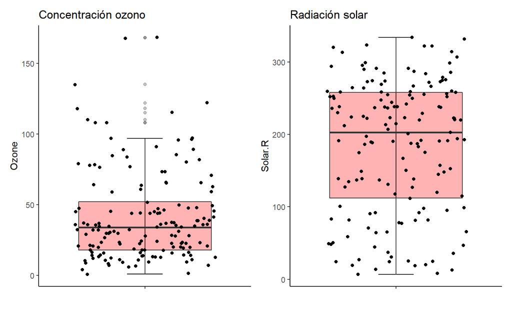

```r
graph1 <- completeData %>%
  drop_na(Ozone) %>%
  ggplot(aes(x="", y=Ozone)) +
  stat_boxplot(geom = "errorbar",
               width = 0.2) +
  geom_boxplot(fill="red", alpha = 0.3) +
  geom_jitter() +
  labs(x = "") +
  ggtitle("Concentración ozono") +
  theme_classic()

graph2 <- completeData %>%
  drop_na(Solar.R) %>%
  ggplot(aes(x="", y=Solar.R)) +
  stat_boxplot(geom = "errorbar",
               width = 0.2) +
  geom_boxplot(fill="red", alpha = 0.3) +
  geom_jitter() +
  labs(x = "") +
  ggtitle("Radiación solar") +
  theme_classic()

graph1+graph2
```

Podemos observar que para la variable Ozone, el algoritmo *pmm* produjo una gran cantidad de *outliers*. Por lo que en este caso es preferible usar la imputación simple que la imputación mediante el algoritmo *pmm*.

# Skewness o asimetría en la distribución de los datos

```r
library(e1071)
skewness(completeData$Ozone)
```

```
## [1] 1.438012
```

```r
skewness(completeData$Solar.R)
```

```
## [1] -0.4124611
```

```r
skewness(completeData$Wind)
```

```
## [1] 0.3410275
```

```r
skewness(completeData$Temp)
```

```
## [1] -0.3705073
```

```r
skewness(completeData$Month)
```

```
## [1] -0.00234481
```

```r
skewness(completeData$Day)
```

```
## [1] 0.002600083
```

# Transformación de los datos

Después de realizar las transformaciones mediante los métodos log+1, raíz cuadrada y raiz cubida, se determinó que está ultima es la que mejor aproxima los datos a la normalidad.

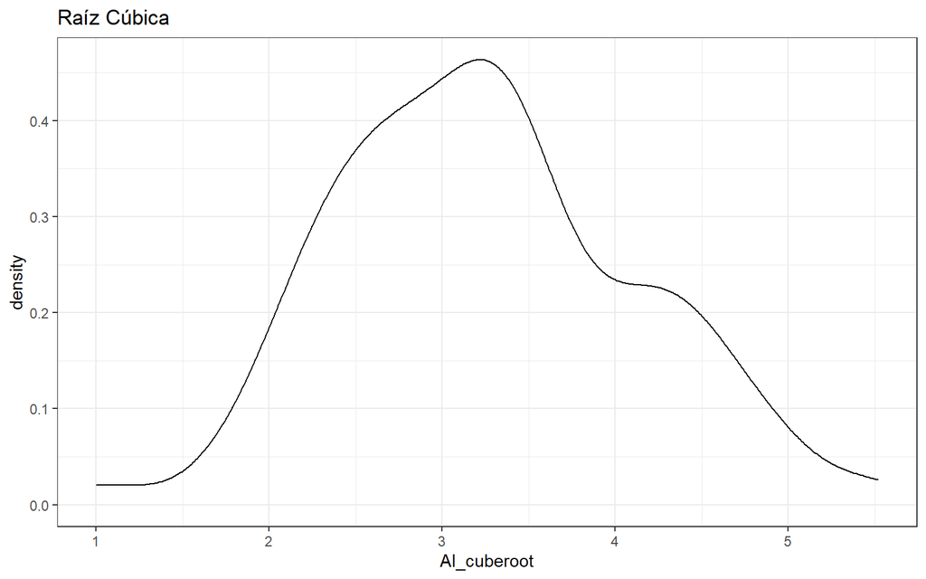

```r
Al_cuberoot <- sign(completeData$Ozone)* abs(completeData$Ozone)^(1/3)
ggplot(completeData, aes(Al_cuberoot)) +geom_density()+
  theme_bw()+ggtitle('Raíz Cúbica')
```

```r
shapiro.test(Al_cuberoot) #Para confirmar normalidad de los datos
```

```
##
##  Shapiro-Wilk normality test
##
## data:  Al_cuberoot
## W = 0.98682, p-value = 0.1565
```

No se rechazo H0, por lo que se asume normalidad.

# ¿Mejor predictor para estimar la variable Ozono?

Se debe asumir que la variable que se use para estimar el ozono debe estar correlacionado con este. Por lo tanto, se realizó una matriz de correlación.

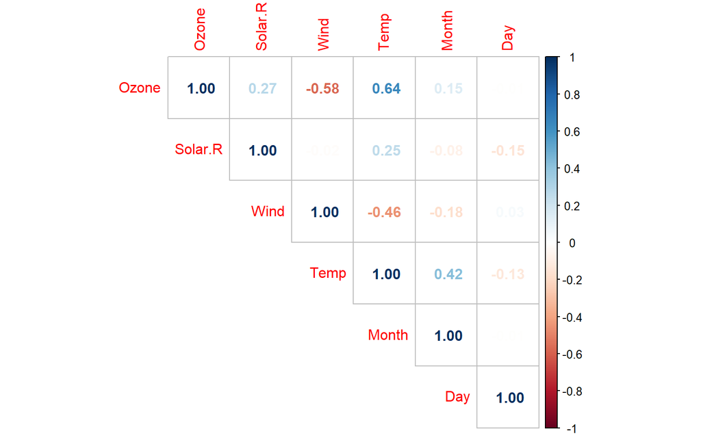

```r
library(corrplot)
corr<-round(cor(completeData), 2) #redondeamos a 1 decimal
corrplot(corr, method="number", type="upper")
```

Con base en lo anterior, podemos asegurar que la variable Temp sería el mejor predictor de Ozone debido a que es la que tiene una mayor correlación.